# Workflow for AFRP CPUE Data

Montana

1/20/2021

## This is the workflow for CPUE calculations on the AFRP masterdabase

Markdown allows you to produce HTML or PDF documents which are useful for communication and sharing code with others. The chunks of code also allow you to seperate code into pieces that make sense together.

You will have to install the R-Markdown package: `install.packages('rmarkdown')`. This will allow you to open the raw markdown files.

##### Load Libraries

```r
library (ggplot2)
library(readr)
library(dplyr)
library(tidyr)
library(tidyverse)
library(gridExtra)
```

##### Load in Data

These data are exported from the master database. You should set your working directory to wherever you keep those files.

```r
fish = read.csv("FISH_MEASUREMENT_whole.csv")
sample = read.csv("FISH_SAMPLE.csv")
sites = read.csv("SITES.csv")
shoreline_length = read.csv("BEFsites_LengthAndHabitat.csv")
```

##### Combine datasheets and filter results

The filter function in tidyverse is very useful and straightfoward. Simply write in the name of the column you wish to filter by and then indicate what you would like to filter for. If I wanted multiple gear types I might write `GEAR %in% c("TPN", "BEF)`. The `%in%` operator says to filter for **any** of those criteria in your list. If I did not want to indicate species, I would remove that filter criteria entirely. This would return all fish of all species that meet the other criteria.

Note - the site column might need to be renamed `SITE_N` to join with all_data depending on the CSV version you have.

```r
# Join/Filter ---------
all_data = left_join(fish, sample, by = "YSAMP_N") %>%
  left_join(sites, by = "SITE_N") %>%
  left_join(shoreline_length, by = "SITE_N") %>%
  separate(SITE_N,  into = c("GEAR", "WATER","SITE")) %>%
  filter(WATER == "LML",
         GEAR == "BEF",
         ### single out or remove specific species
         (SPECIES != "NF" & SPECIES != ""),
         ### remove sites where no one described habitat
         (HAB_1 != "NA" & HAB_1 != ""),
         ### remove sites with no described site
         SITE != "NA",
         GEAR_CODE == "NAF",
         YEAR > 1999,
         MONTH < 8
  )
```

##### Calculate CPUE data using `EFFORT` in `seconds`

Tommy - CPUE_wide is the format (I think) you were looking for. It also turned out to be a better way of making sure there were zeroes where there needed to be. However, it still looks like there are multiple efforts for some of the day/site combinations even when its filtered for `NAF`.

CPUE_long is the format I had before for the other plots below.

```r
CPUE_wide = all_data %>%
  select(YSAMP_N, DSAMP_N, YEAR, SEASON, WATER, SITE, SPECIES,
         FISH_N, WEIGHT, LENGTH, HAB_1, GEAR, EFFORT) %>%
  group_by(WATER, DSAMP_N, YEAR, SITE, SPECIES, EFFORT, HAB_1) %>%
  count() %>% ## Abundance per year, site, species
  mutate(CPUE_seconds = n / EFFORT) %>%
  select(-n) %>%
  pivot_wider(names_from = SPECIES, values_from = CPUE_seconds) %>%
  mutate(across(everything(), ~replace_na(.x,0)))

head(CPUE_wide) ## Note the multiple efforts per site/DSAMP_N
```

```
## # A tibble: 6 x 22
## # Groups:   WATER, DSAMP_N, YEAR, SITE, EFFORT, HAB_1 [6]
##   WATER DSAMP_N  YEAR SITE  EFFORT HAB_1     LLS      LT      PS     SMB      WS
##   <chr>   <int> <int> <chr>  <dbl> <chr>   <dbl>   <dbl>   <dbl>   <dbl>   <dbl>
## 1 LML         1  2000 001      316 R     0.00316 0       0       0.0222  0.00633
## 2 LML         1  2000 001      384 R     0.00521 0       0       0.00260 0
## 3 LML         1  2000 001      219 R     0       0.00913 0       0.0457  0
## 4 LML         1  2000 001      277 R     0       0.00722 0.00722 0.116   0
## 5 LML         1  2000 001      361 R     0       0       0.00277 0.0443  0
## 6 LML         1  2000 001      638 R     0       0       0.00157 0.0188  0
## # ... with 11 more variables: ST <dbl>, SS <dbl>, CC <dbl>, CS <dbl>, BB <dbl>,
## #   RT <dbl>, MM <dbl>, RS <dbl>, BND <dbl>, RWF <dbl>, NRD <dbl>
```

```r
CPUE_long = CPUE_wide %>%
  pivot_longer(cols = LLS:length(CPUE_wide),names_to = "SPECIES", values_to = "CPUE_seconds" )
head(CPUE_long)
```

```
## # A tibble: 6 x 8
## # Groups:   WATER, DSAMP_N, YEAR, SITE, EFFORT, HAB_1 [1]
##   WATER DSAMP_N  YEAR SITE  EFFORT HAB_1 SPECIES CPUE_seconds
##   <chr>   <int> <int> <chr>  <dbl> <chr> <chr>          <dbl>
## 1 LML         1  2000 001      316 R     LLS          0.00316
## 2 LML         1  2000 001      316 R     LT           0
## 3 LML         1  2000 001      316 R     PS           0
## 4 LML         1  2000 001      316 R     SMB          0.0222
## 5 LML         1  2000 001      316 R     WS           0.00633
## 6 LML         1  2000 001      316 R     ST           0
```

###### Plotting the CPUE data for all species from spring NAF boat electrofishing

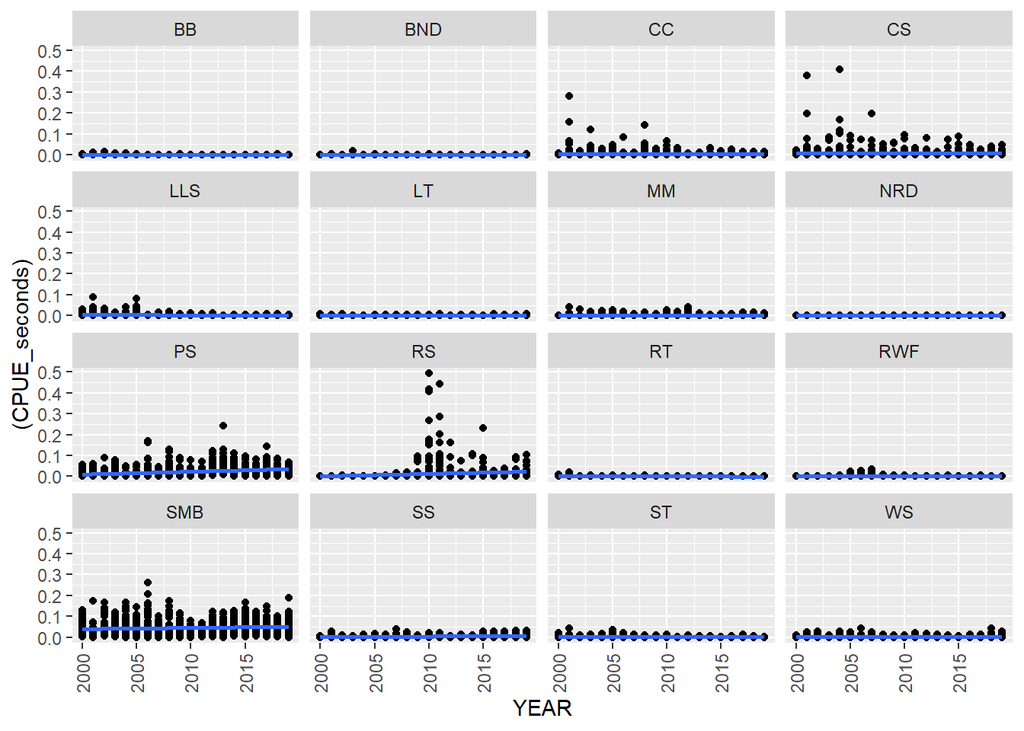

```r
CPUE_long %>%
  ggplot(aes(x = YEAR, y = (CPUE_seconds))) +
  geom_point() +
  geom_smooth(method = "lm") +
  theme(axis.text.x = element_text(angle = 90, vjust = 0.5, hjust=1)) +
  facet_wrap(~SPECIES)
```

##### Plotting the CPUE data for SMB

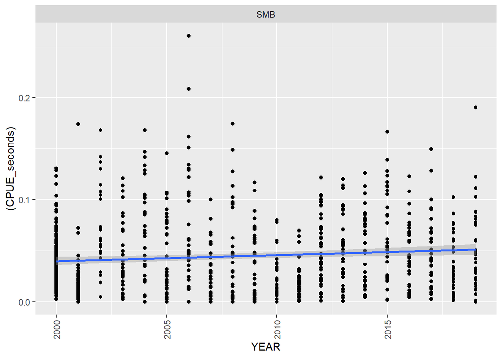

```r
CPUE_long %>%
  filter(SPECIES == "SMB") %>%
  ggplot(aes(x = YEAR, y = (CPUE_seconds))) +
  geom_point() +
  geom_smooth(method = "lm") +
  theme(axis.text.x = element_text(angle = 90, vjust = 0.5, hjust=1)) +   facet_wrap(~SPECIES)
```

##### Calculate CPUE data using `EFFORT` in `shoreline_length`

```r
CPUE_wide_shore = all_data %>%
  select(YSAMP_N, DSAMP_N, YEAR, SEASON, WATER, SITE, SPECIES,
       WEIGHT, LENGTH, HAB_1, GEAR, EFFORT, Shape_Length) %>%
  group_by(WATER, DSAMP_N, YEAR, SITE, SPECIES, EFFORT, HAB_1, Shape_Length) %>%
  count() %>% ## Abundance per year, site, species
  mutate(CPUE_shoreline = n / Shape_Length) %>%
  select(-n) %>%
  pivot_wider(names_from = SPECIES, values_from = CPUE_shoreline) %>%
  mutate(across(everything(), ~replace_na(.x,0)))

CPUE_long_shore = CPUE_wide_shore %>%
  pivot_longer(cols = LLS:length(CPUE_wide_shore),names_to = "SPECIES", values_to = "CPUE_shoreline" )
```

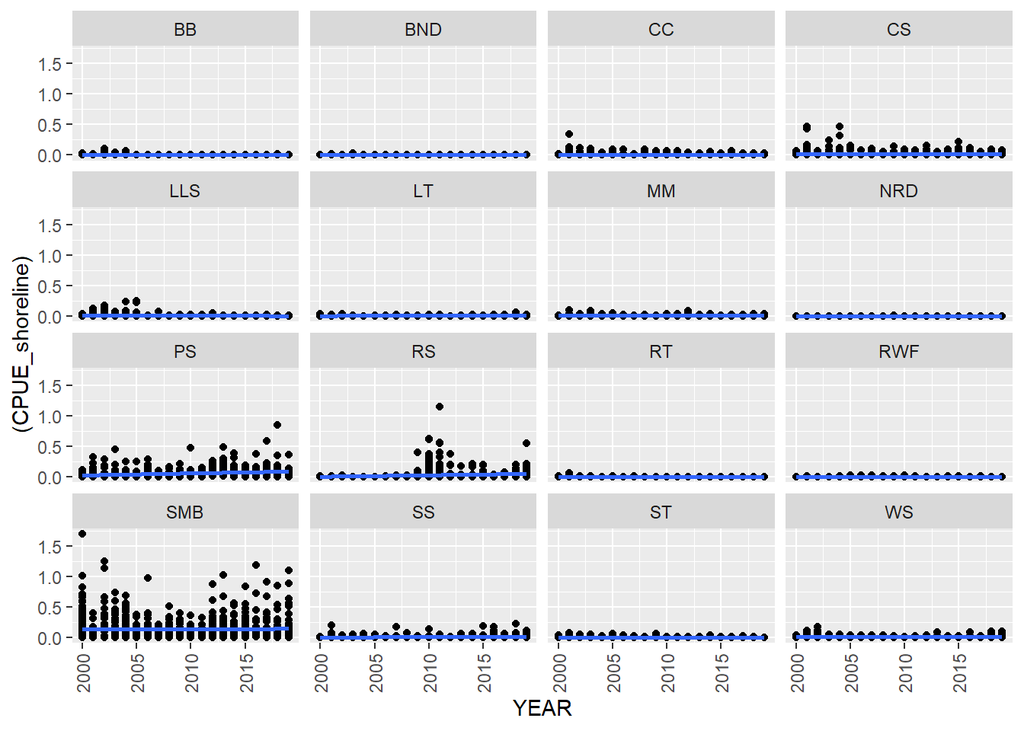

```r
CPUE_long_shore %>%
  ggplot(aes(x = YEAR, y = (CPUE_shoreline))) +
  geom_point() +
  geom_smooth(method = "lm") +
  theme(axis.text.x = element_text(angle = 90, vjust = 0.5, hjust=1)) +
  facet_wrap(~SPECIES)
```

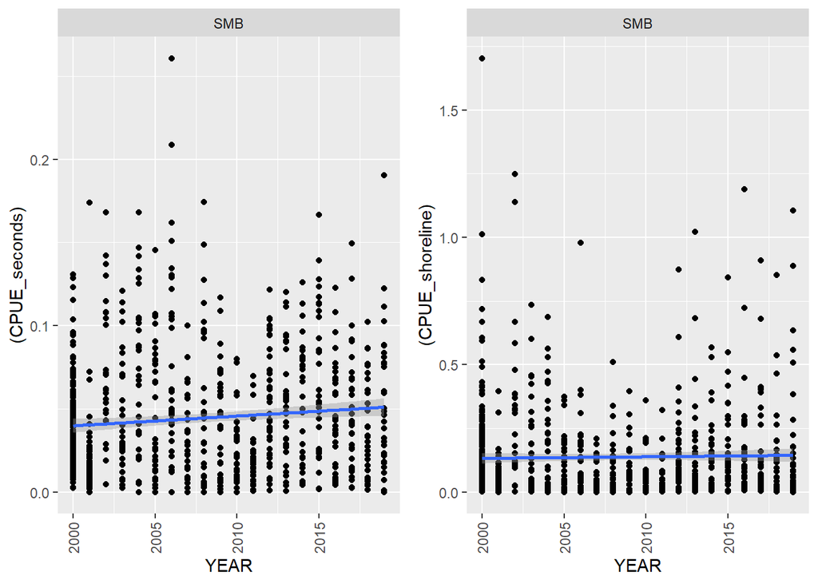

```r
a = CPUE_long %>%
  filter(SPECIES == "SMB") %>%
  ggplot(aes(x = YEAR, y = (CPUE_seconds))) +
  geom_point() +
  geom_smooth(method = "lm") +
  theme(axis.text.x = element_text(angle = 90, vjust = 0.5, hjust=1)) +   facet_wrap(~SPECIES)
b = CPUE_long_shore %>%
  filter(SPECIES == "SMB") %>%
  ggplot(aes(x = YEAR, y = (CPUE_shoreline))) +
  geom_point() +
  geom_smooth(method = "lm") +
  theme(axis.text.x = element_text(angle = 90, vjust = 0.5, hjust=1)) +   facet_wrap(~SPECIES)
grid.arrange(a,b,ncol = 2)
```

## We Can also use the `all_data` to run other fun analyses!

##### Here is average length represented by habitat and overall trend through time

While it is not as apparent in these compound graphs, there seem to be some interesting trends between CPUE and average size through time.

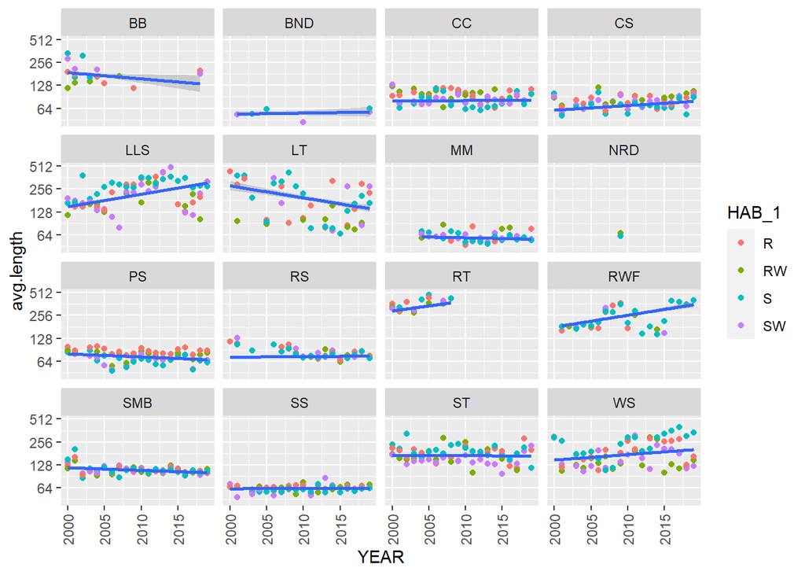

```r
all_data %>%
  group_by(YEAR, SPECIES, HAB_1, SEASON) %>%
  mutate(avg.length = mean(LENGTH, na.rm=T)) %>%
  ggplot(aes(YEAR, y = avg.length)) +
  geom_point(aes(color = HAB_1)) +
  geom_smooth(method = "lm") +
  scale_y_continuous(trans='log2') +
  theme(axis.text.x = element_text(angle = 90,
                                   vjust = 0.5, hjust=1)) +
  facet_wrap(~SPECIES)
```

#### Checking to see if the habitats are the same

It looks like all the habitats match up except for Site 1 in HAL that is just missing that information.

```r
all_data = left_join(fish, sample, by = "YSAMP_N") %>%
  left_join(sites, by = "SITE_N") %>%
  left_join(shoreline_length, by = "SITE_N") %>%
  filter(GEAR == "BEF") %>%
  select(WATER, SITE_N, HAB_1) %>%
  unique() %>%
  left_join(shoreline_length, by = "SITE_N") %>%
  filter(WATER %in% c("FBL", "HAL", "LML"),
         SiteNum != "NA") %>%
  mutate(check = HAB_1 == Habitat) %>%
  filter(check == "FALSE"| is.na(check))
print(all_data)
```

```
##   WATER      SITE_N HAB_1 Water SiteNum Shape_Length Habitat check
## 1   HAL BEF.HAL.001  <NA>   HAL       1     51.77533      SW    NA
```

## HAL Brook Trout Data for Trap Nets

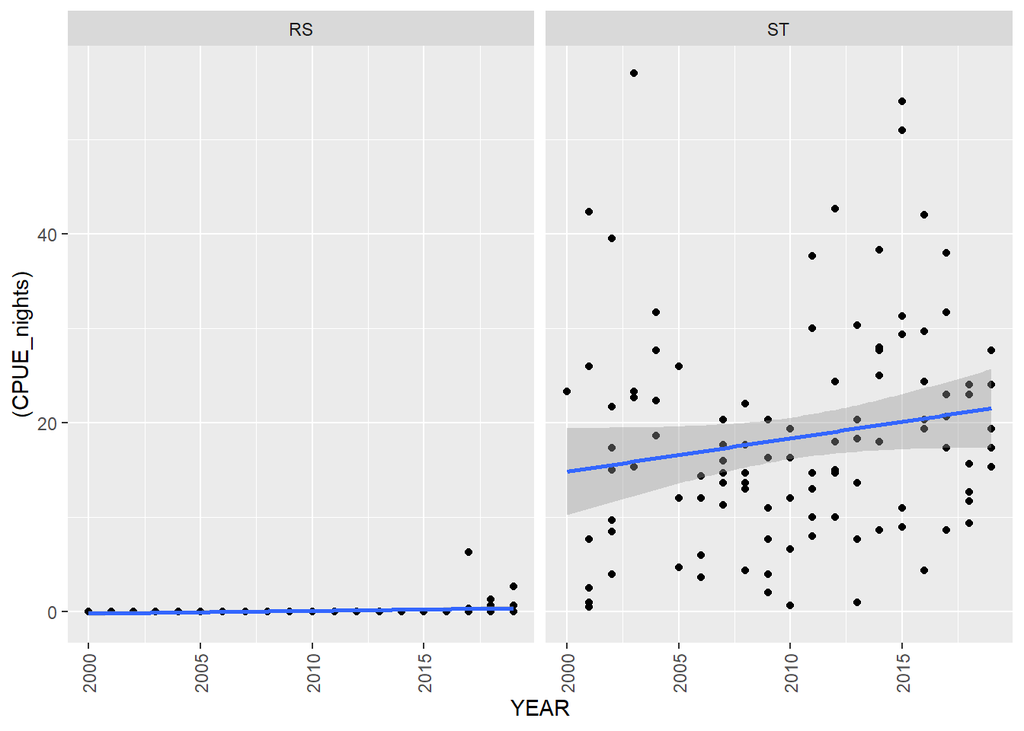

```r
# Join/Filter ---------
all_data = left_join(fish, sample, by = "YSAMP_N") %>%
  left_join(sites, by = "SITE_N") %>%
  separate(SITE_N,  into = c("GEAR", "WATER","SITE")) %>%
  filter(WATER == "HAL",
         GEAR == "TPN",
         YEAR > 1999,
         ### single out or remove specific species
         (SPECIES != "NF" & SPECIES != ""),
          MONTH > 8)

## Calculate CPUE information ------
CPUE_wide = all_data %>%
  select(YSAMP_N, DSAMP_N, YEAR, SEASON, WATER, SITE, SPECIES,
         FISH_N, WEIGHT, LENGTH, HAB_1, GEAR, EFFORT) %>%
  group_by(WATER, DSAMP_N, YEAR, SITE, SPECIES, EFFORT, HAB_1) %>%
  count() %>% ## Abundance per year, site, species
  mutate(CPUE_nights = n / EFFORT) %>%
  select(-n) %>%
  pivot_wider(names_from = SPECIES, values_from = CPUE_nights) %>%
  mutate(across(everything(), ~replace_na(.x,0)))

CPUE_long = CPUE_wide %>%
  pivot_longer(cols = ST:RS,names_to = "SPECIES", values_to = "CPUE_nights" )

# ST by site
CPUE_long %>%
  ggplot(aes(x = YEAR, y = (CPUE_nights))) +
  geom_point() +
  geom_smooth(method = "lm") +
  theme(axis.text.x = element_text(angle = 90, vjust = 0.5, hjust=1)) +
  facet_wrap(~SPECIES)
```